# Assignment 3: Logistic Regression

Varun Bhakhri and Riya Saini

2024-04-17

# Question 1

##### Code Setup:

```r
rm(list = ls())

library(haven)
library(arm)
library(tidyverse)
library(car)
library(plotfunctions)
library(kableExtra)
library(stargazer)
library(lmtest)
library(dplyr)

options(scipen = 999)

load("cpln505_assignment3_voting_data_abb.rda")
```

## Task 1. Select variables you think relevant to the analysis. Recategorize the variables as you see fit. Remove categories as needed. Make a table to summarize the variables by year (i.e., 2012 and 2016). For categorical variables, summarize the share of each category instead of the mean, standard deviation, minimum, and maximum. Discuss your variable selection and cleaning, as well as any notable pattern you see in the data. Use plots and graphs for exploratory data analysis.

### Data Cleaning, Exploration and Recategorization:

##### A test dataframe with correctly named variables was created to understand distribution of variables for subsequent cleaning and recategorizing:

```r
dat_test <- dat.voting %>%
  filter(VCF0004 == 2012 | VCF0004 == 2016) %>%
  rename(candidate = VCF0704a,
         year = VCF0004,
         race = VCF0105a,
         age = VCF0101,
         gender = VCF0104,
         income = VCF0114,
         religion = VCF0128,
         education = VCF0140a,
         marital = VCF0147,
         class = VCF0148a,
         party = VCF0302,
         hispanic = VCF0108,
         south = VCF0113)
```

##### Histograms were created to understand the distribution of variable categories to be able to clean and recategorize the data:

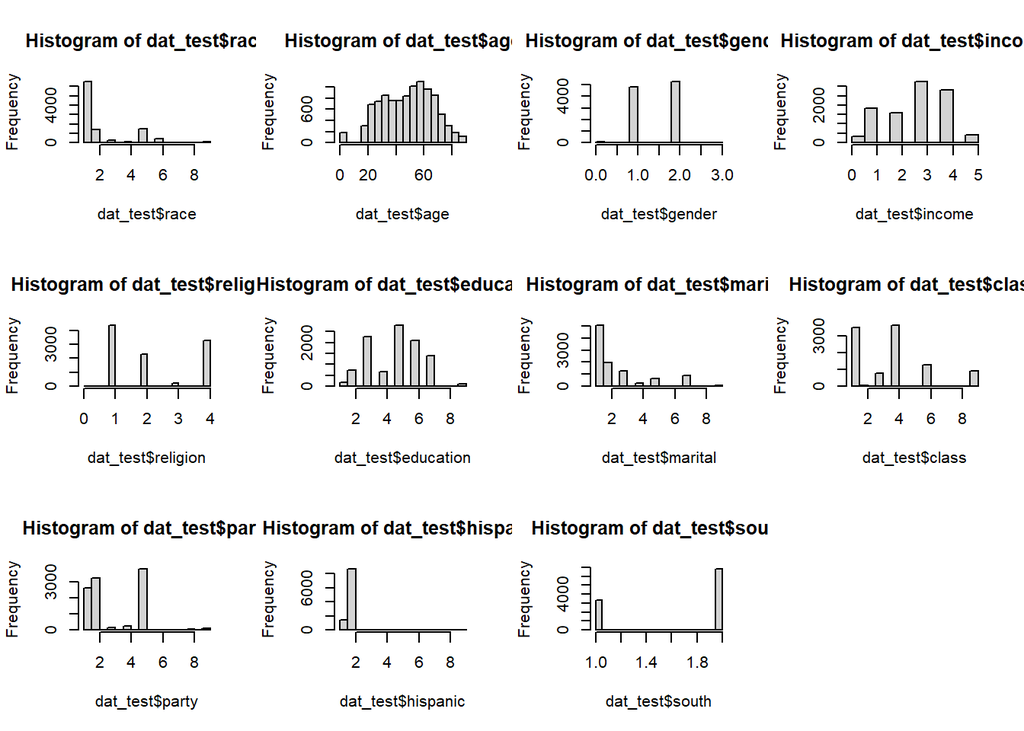

```r
par(mfrow = c(3,4))

hist(dat_test$race)
hist(dat_test$age)
hist(dat_test$gender)
hist(dat_test$income)
hist(dat_test$religion)
hist(dat_test$education)
hist(dat_test$marital)
hist(dat_test$class)
hist(dat_test$party)
hist(dat_test$hispanic)
hist(dat_test$south)
```

##### The variables were recategorized as follows to better suit a logistical regression model:

```r
dat <- dat.voting %>%
  filter(VCF0004 == 2012 | VCF0004 == 2016) %>%
  rename(candidate = VCF0704a,
         year = VCF0004,
         race = VCF0105a,
         age = VCF0101,
         gender = VCF0104,
         income = VCF0114,
         religion = VCF0128,
         education = VCF0140a,
         marital = VCF0147,
         class = VCF0148a,
         party = VCF0302,
         hispanic = VCF0108,
         south = VCF0113) %>%
  filter(age != 0, race != 9, candidate != 0, gender != 0, gender != 3, income != 0, religion != 0, education != 8, education != 9, class != 0, marital != 9, party != 0, class !=9, hispanic != 8, hispanic != 9, south != 0) %>%
  mutate(candidate = as.factor(case_when(
    candidate == "1" ~ "democrat",
    candidate == "2" ~ "republican",
    TRUE ~ as.character(candidate)
  ))) %>%
  mutate(race = as.factor(case_when(
    race == 1 ~ "white",
    race == 2 ~ "black",
    TRUE ~ "other"
  ))) %>%
  mutate(age = as.factor(case_when(
    age >= 17 & age < 35 ~ "youth",
    age >= 35 & age < 65 ~ "middle age",
    age >= 65 ~ "retirees"
  ))) %>%
  mutate(gender = as.factor(case_when(
    gender == 1 ~ "male",
    gender == 2 ~ "female",
    TRUE ~ "other"
  ))) %>%
  mutate(income = as.factor(case_when(
    income %in% c(1, 2) ~ "low",
    income == 3 ~ "middle",
    income %in% c(4, 5) ~ "high",
    TRUE ~ "other"
  ))) %>%
  mutate(religion = as.factor(case_when(
    religion == 1 ~ "protestant",
    religion == 2 ~ "catholic",
    TRUE ~ "other"
  ))) %>%
  mutate(education = as.factor(case_when(
    education %in% c(1, 2) ~ "no hs",
    education %in% c(3, 4) ~ "hs",
    education %in% c(5, 6, 7) ~ "college",
    TRUE ~ "other"
  ))) %>%
  mutate(marital = as.factor(case_when(
    marital == 1 ~ "married",
    TRUE ~ "unmarried"
  ))) %>%
  mutate(class = as.factor(case_when(
    class %in% c(1, 2, 3) ~ "working",
    class %in% c(4, 5, 6) ~ "middle",
    TRUE ~ "other"
  ))) %>%
  mutate(party = as.factor(case_when(
    party == 1 ~ "republican",
    party == 5 ~ "democrat",
    TRUE ~ "other"
  ))) %>%
  mutate(hispanic = as.factor(case_when(
    hispanic == 1 ~ "hispanic",
    TRUE ~ "non-hispanic"
  ))) %>%
  mutate(south = as.factor(case_when(
    south == 1 ~ "south",
    TRUE ~ "non-south"
  )))
```

Race categories were reduced to white, black and other  
Age was recategorised from continuous to categorical data. This was done as age categories based on voter’s stages in life may more accurately represent voting behavior. Age 18-35 were categorised as young voters, age 35-65 as middle age voters and age 65+ as retirees.  
Gender was categorised as male and female. “other” gender category was removed since it existed only in the 2016 data and not in 2012.  
Income was recategorised into low, middle and high in 3 equal quatiles  
Religion was recategorised to protestant, catholic and other for a better distribution of categories. Jews were included in the other category as there were very few jewish voters in the data.  
Education was recategorised into no high school high school and college for easier interpretation of categories in the logistic regression model.  
Marital status was recategorised to married and unmarried for a better distribution of values in each category and a simpler interpretation.  
Class was recategorised to working class and middle class  
Party identification was recategorised to republican, democrat and other, better reflecting the two party majority in the US  
Hispanic was simplified to hispanic and non hispanic  
South categories were retained as south and non south.

##### Seaprate dataframes were created for 2012 and 2016 voter data and summarised:

```r
dat_2012 <- dat %>%
  filter(year == 2012) %>%
  dplyr :: select(-year)

dat_2016 <- dat %>%
  filter(year == 2016) %>%
  dplyr :: select(-year)

summary_cats_2012 <- dat_2012 %>%
  pivot_longer(cols = everything(), names_to = "Category", values_to = "Value") %>%
  count(Category, Value) %>%
  group_by(Category) %>%
  mutate(Percentage = n / sum(n) * 100)
names(summary_cats_2012) <- c("Category", "Value", "2012_Count", "2012_Percentage")

summary_cats_2016 <- dat_2016 %>%
  pivot_longer(cols = everything(), names_to = "Category", values_to = "Value") %>%
  count(Category, Value) %>%
  group_by(Category) %>%
  mutate(Percentage = n / sum(n) * 100)

names(summary_cats_2016) <- c("Category", "Value", "2016_Count", "2016_Percentage")

combined_summary <- inner_join(summary_cats_2012, summary_cats_2016)
kable(combined_summary, digits = 2)
```

| Category | Value | 2012_Count | 2012_Percentage | 2016_Count | 2016_Percentage |
| --- | --- | --- | --- | --- | --- |
| age | middle age | 2218 | 57.97 | 1258 | 53.49 |
| age | retirees | 900 | 23.52 | 613 | 26.06 |
| age | youth | 708 | 18.50 | 481 | 20.45 |
| candidate | democrat | 2249 | 58.78 | 1238 | 52.64 |
| candidate | republican | 1577 | 41.22 | 1114 | 47.36 |
| class | middle | 2191 | 57.27 | 1389 | 59.06 |
| class | working | 1635 | 42.73 | 963 | 40.94 |
| education | college | 2450 | 64.04 | 1712 | 72.79 |
| education | hs | 1089 | 28.46 | 538 | 22.87 |
| education | no hs | 287 | 7.50 | 102 | 4.34 |
| gender | female | 1947 | 50.89 | 1269 | 53.95 |
| gender | male | 1879 | 49.11 | 1083 | 46.05 |
| hispanic | hispanic | 545 | 14.24 | 192 | 8.16 |
| hispanic | non-hispanic | 3281 | 85.76 | 2160 | 91.84 |
| income | high | 1257 | 32.85 | 984 | 41.84 |
| income | low | 1153 | 30.14 | 600 | 25.51 |
| income | middle | 1416 | 37.01 | 768 | 32.65 |
| marital | married | 2062 | 53.89 | 1281 | 54.46 |
| marital | unmarried | 1764 | 46.11 | 1071 | 45.54 |
| party | democrat | 1668 | 43.60 | 931 | 39.58 |
| party | republican | 1027 | 26.84 | 747 | 31.76 |
| party | other | 1131 | 29.56 | 674 | 28.66 |
| race | other | 728 | 19.03 | 333 | 14.16 |
| race | black | 724 | 18.92 | 235 | 9.99 |
| race | white | 2374 | 62.05 | 1784 | 75.85 |
| religion | catholic | 904 | 23.63 | 535 | 22.75 |
| religion | other | 1151 | 30.08 | 731 | 31.08 |
| religion | protestant | 1771 | 46.29 | 1086 | 46.17 |
| south | non-south | 2606 | 68.11 | 1644 | 69.90 |
| south | south | 1220 | 31.89 | 708 | 30.10 |

##### Plots were created to explore trends and patterns in voting data for 2012 and 2016:

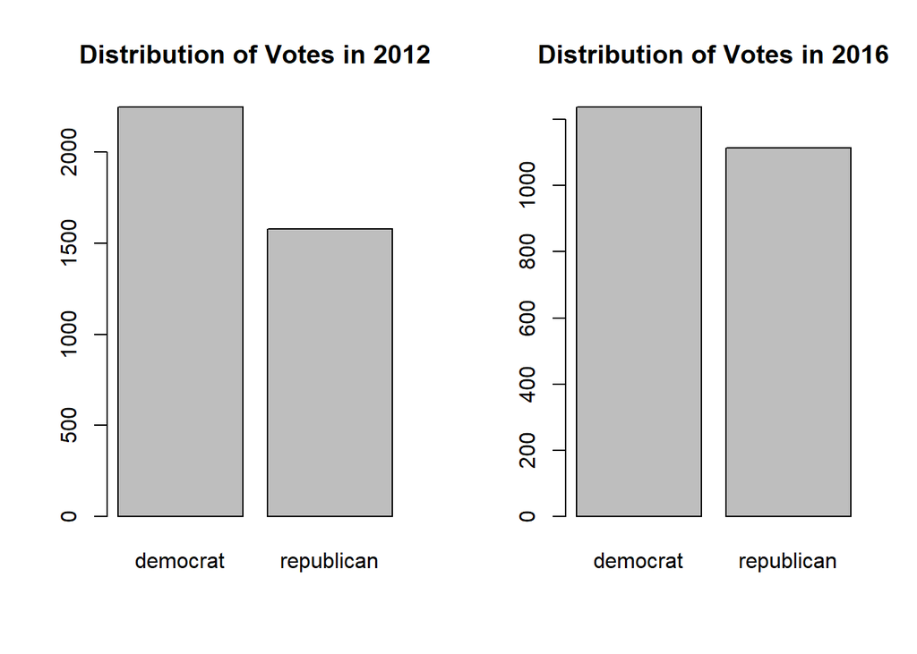

```r
par(mfrow = c(1, 2))

plot(dat_2012$candidate, main = "Distribution of Votes in 2012")
plot(dat_2016$candidate, main = "Distribution of Votes in 2016")
```

The number of voters voting for either candidate was more balanced in 2016

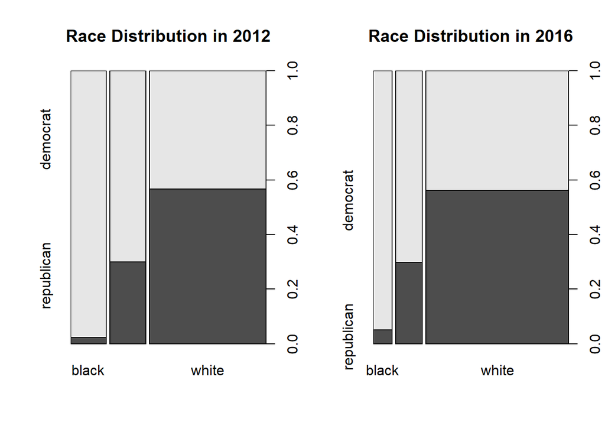

```r
par(mfrow = c(1, 2))
plot(dat_2012$race, dat_2012$candidate, main = "Race Distribution in 2012", xlab = "", ylab = "")
plot(dat_2016$race, dat_2016$candidate, main = "Race Distribution in 2016", xlab = "", ylab = "")
```

The distribution of voters by race appears to be relatively unchanged

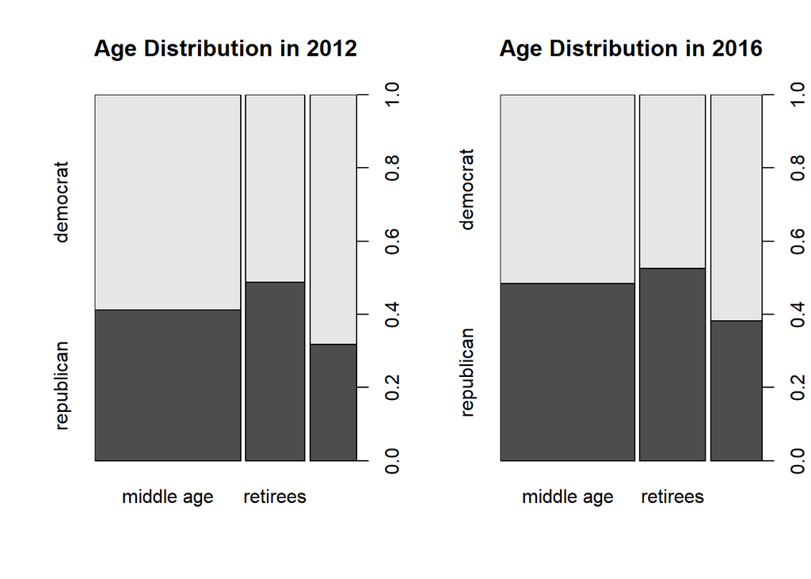

```r
par(mfrow = c(1, 2))
plot(dat_2012$age, dat_2012$candidate, main = "Age Distribution in 2012", xlab = "", ylab = "")
plot(dat_2016$age, dat_2016$candidate, main = "Age Distribution in 2016", xlab = "", ylab = "")
```

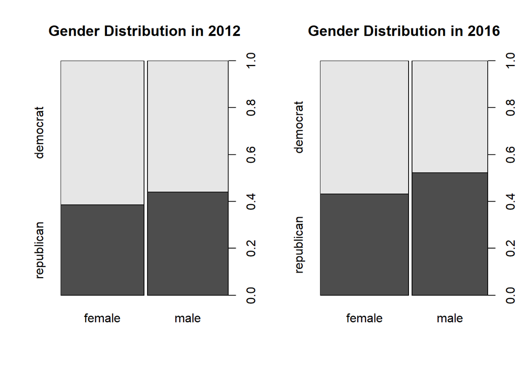

```r
par(mfrow = c(1, 2))
plot(dat_2012$gender, dat_2012$candidate, main = "Gender Distribution in 2012", xlab = "", ylab = "")
plot(dat_2016$gender, dat_2016$candidate, main = "Gender Distribution in 2016", xlab = "", ylab = "")
```

Male voters apear to continue to be more likely to vote republican than female voters in 2016

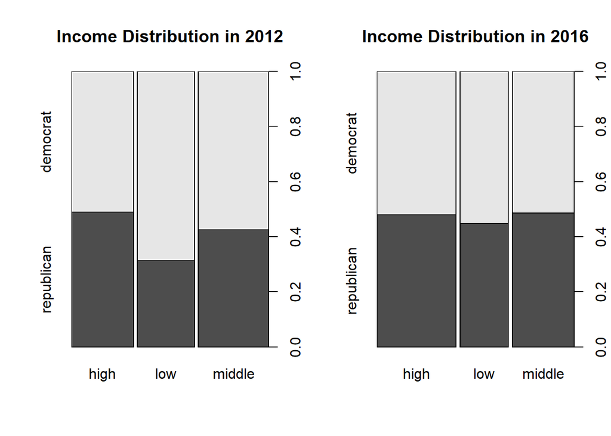

```r
par(mfrow = c(1, 2))
plot(dat_2012$income, dat_2012$candidate, main = "Income Distribution in 2012", xlab = "", ylab = "")
plot(dat_2016$income, dat_2016$candidate, main = "Income Distribution in 2016", xlab = "", ylab = "")
```

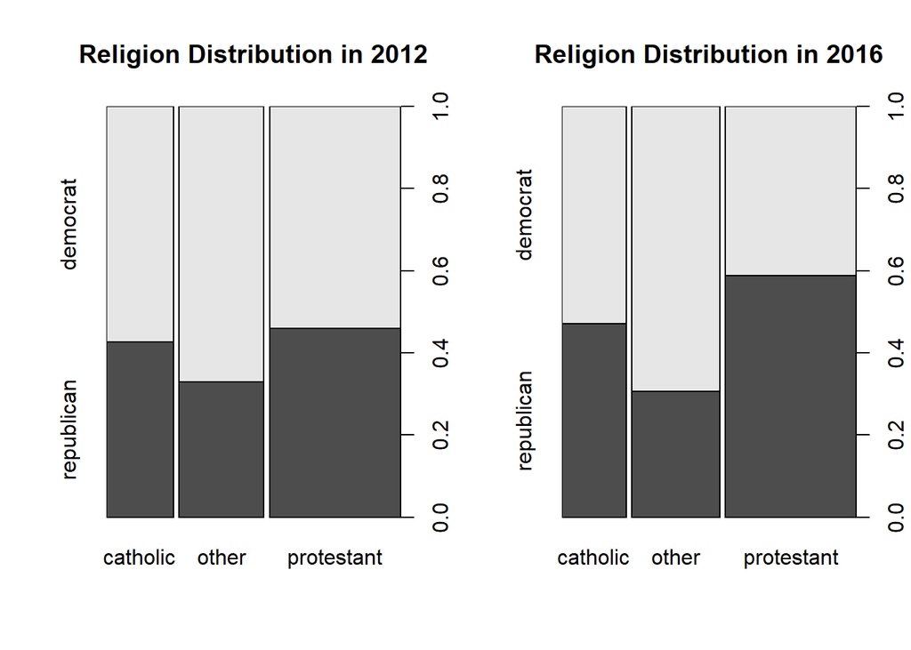

```r
par(mfrow = c(1, 2))
plot(dat_2012$religion, dat_2012$candidate, main = "Religion Distribution in 2012", xlab = "", ylab = "")
plot(dat_2016$religion, dat_2016$candidate, main = "Religion Distribution in 2016", xlab = "", ylab = "")
```

More catholic and protestant voters appear to have voted republican in 2016

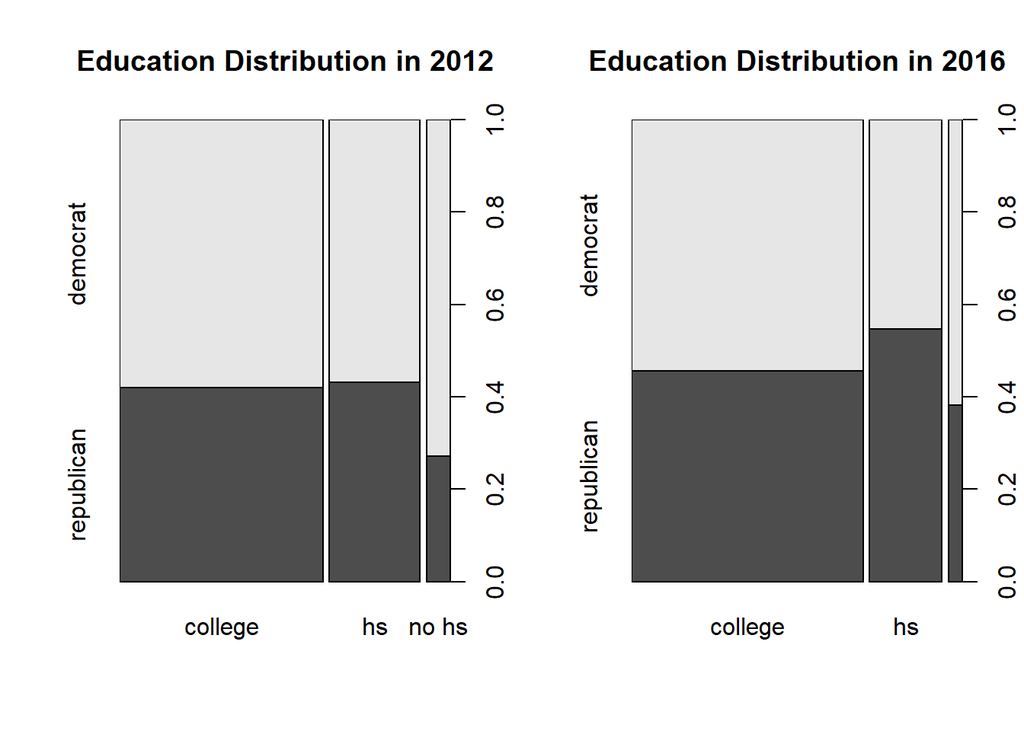

```r
par(mfrow = c(1, 2))
plot(dat_2012$education, dat_2012$candidate, main = "Education Distribution in 2012", xlab = "", ylab = "")
plot(dat_2016$education, dat_2016$candidate, main = "Education Distribution in 2016", xlab = "", ylab = "")
```

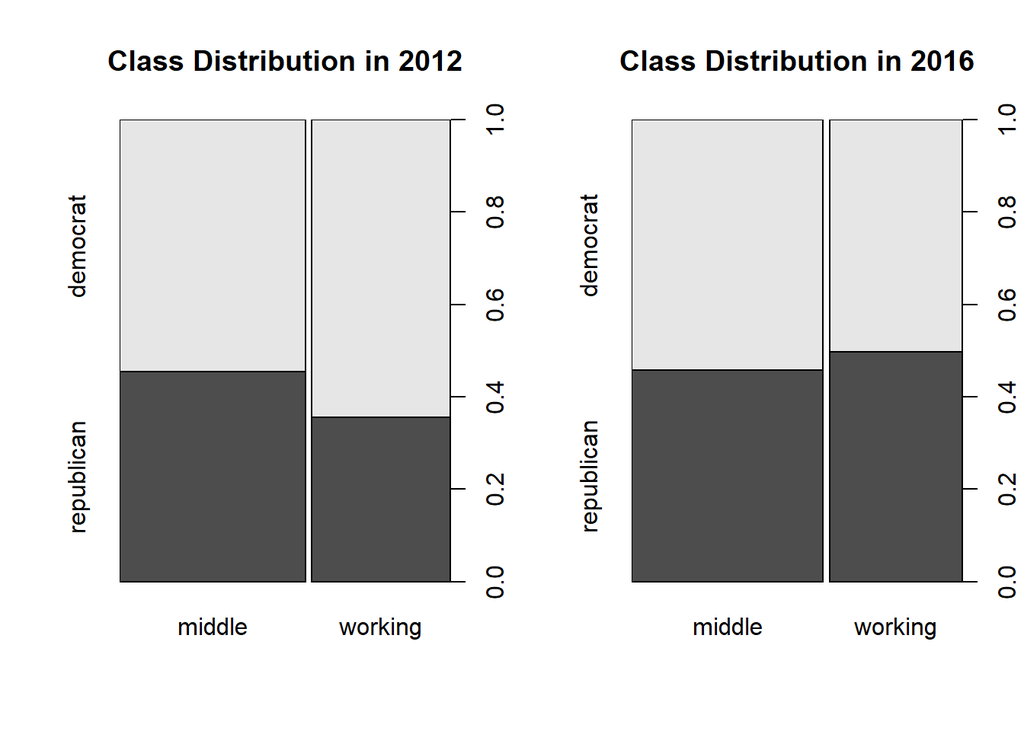

```r
par(mfrow = c(1, 2))
plot(dat_2012$class, dat_2012$candidate, main = "Class Distribution in 2012", xlab = "", ylab = "")
plot(dat_2016$class, dat_2016$candidate, main = "Class Distribution in 2016", xlab = "", ylab = "")
```

Working class voters appear to be much more likely to vote republican in 2016 compared to 2012, and potentially more likely than middle class voters in 2016, reversing a trend.

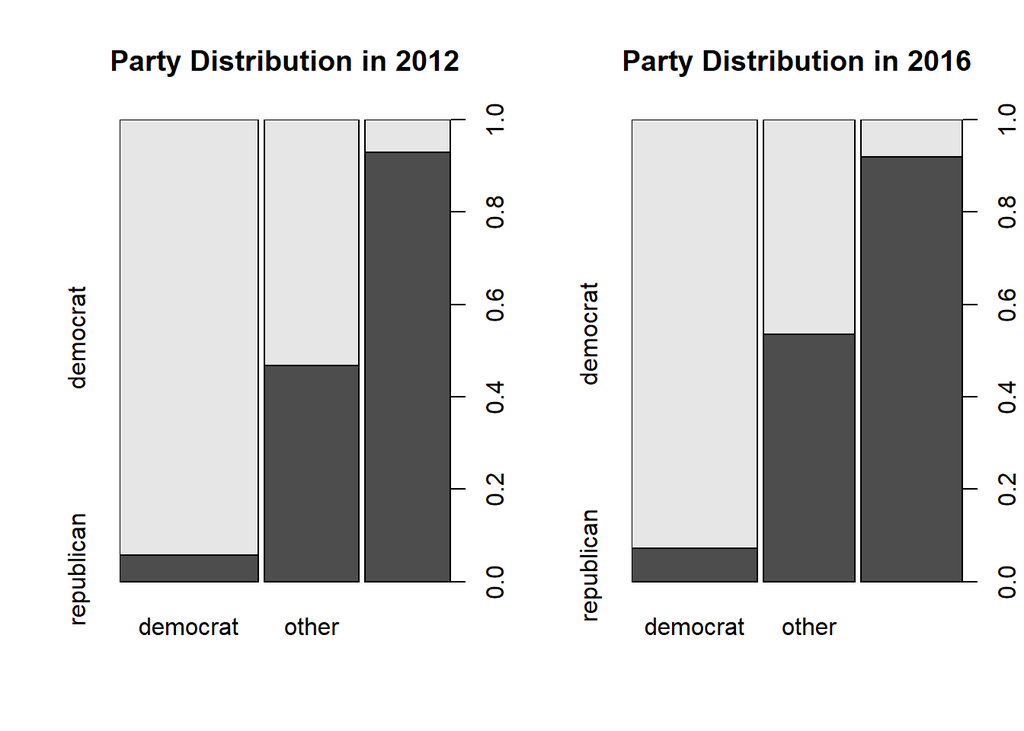

```r
par(mfrow = c(1, 2))
plot(dat_2012$party, dat_2012$candidate, main = "Party Distribution in 2012", xlab = "", ylab = "")
plot(dat_2016$party, dat_2016$candidate, main = "Party Distribution in 2016", xlab = "", ylab = "")
```

The proportion of voters identifying as neither democrat nor republican boting republican appears to have increased in 2016

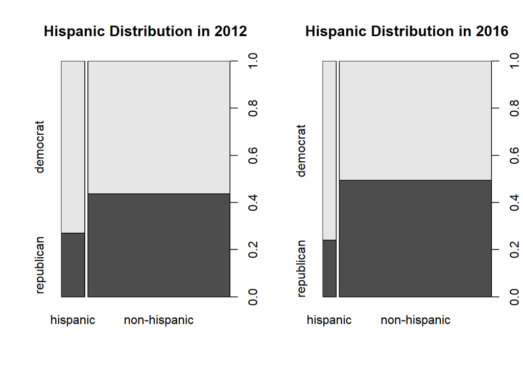

```r
par(mfrow = c(1, 2))
plot(dat_2012$hispanic, dat_2012$candidate, main = "Hispanic Distribution in 2012", xlab = "", ylab = "")
plot(dat_2016$hispanic, dat_2016$candidate, main = "Hispanic Distribution in 2016", xlab = "", ylab = "")
```

The propoertion of hispanic voters viting republican appears to have reduced in 2016

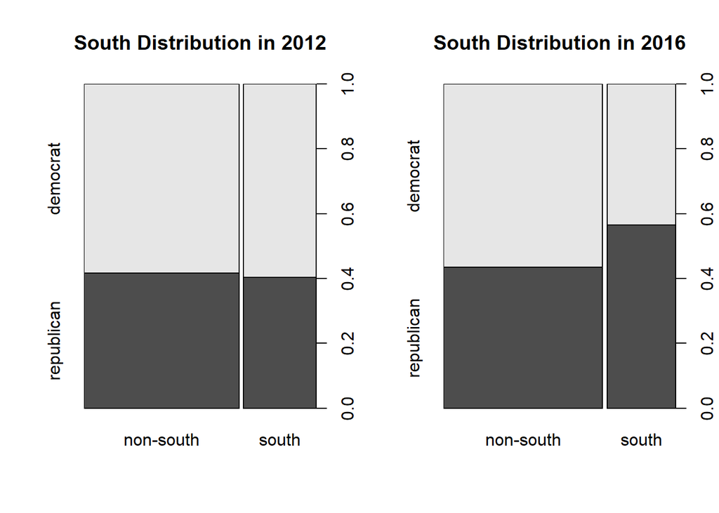

```r
par(mfrow = c(1, 2))
plot(dat_2012$south, dat_2012$candidate, main = "South Distribution in 2012", xlab = "", ylab = "")
plot(dat_2016$south, dat_2016$candidate, main = "South Distribution in 2016", xlab = "", ylab = "")
```

The proportion of voters in southern states voting republican appears to have increased significantly in 2016 and is much greater than that of voters in non south states.

#### Variable selection

Considering our knowledge of the voting trends in 2012 and 2016 and by analysing the distribution of data in this dataset, voter behvaior varied along lines of race, age, gender, educational attianment,class and being in southern states. We would like to investigate if our assumptions are verified in the logistic regression analysis of this dataset. Variables such as party identification and hispanic were also included to investigate the change in voting patterns.

## Task 2. In a neatly organized table, present a binomial logit model for 2012 and a binomial logit model for 2016 using the variable candidate as the dependent variable. You may find an example logit output table in the screenshot at the end of this assignment sheet. The two models may or may not have the same independent variables. Explain how you used theory, significance level, and model fit to select variables. Briefly discuss which variables fell out in the process of modeling building and why. Pay particular attention to variables that were hypothesized to correspond to voting choices but were excluded from the final model. For variables that can be modeled as either numerical or categorical, explain your rationale for using either data type. For categorical variables, explain your choice of the reference category (you may set the reference category manually). For each model, interpret the parameter estimates (coefficients, significance, and model fit). Compare the two models and discuss any differences in the parameter estimates. What do the model outcomes say about how voting patterns changed between the two years? Do these changes meet your expectations?

### Model Building:

##### Reference categories were selected for variables as follows:

```r
dat_2012$education <- relevel(dat_2012$education, ref = "hs")
dat_2016$education <- relevel(dat_2016$education, ref = "hs")

dat_2012$income <- relevel(dat_2012$income, ref = "middle")
dat_2016$income <- relevel(dat_2016$income, ref = "middle")

dat_2012$race <- relevel(dat_2012$race, ref = "black")
dat_2016$race <- relevel(dat_2016$race, ref = "black")

dat_2012$religion <- relevel(dat_2012$religion, ref = "catholic")
dat_2016$religion <- relevel(dat_2016$religion, ref = "catholic")

dat_2012$hispanic <- relevel(dat_2012$hispanic, ref = "non-hispanic")
dat_2016$hispanic <- relevel(dat_2016$hispanic, ref = "non-hispanic")
```

Other reference categories were set to better interpret the results and to achieve better significance levels in the models.

### Model building for 2012:

##### 2012A. All variables were added to the model to assess level of significance for each variable

```r
mod_12_a <- glm(candidate ~ race + age + gender + income + religion + education + marital + class + party + hispanic + south,
                data = dat_2012,
                na.action = na.exclude,
                family = binomial("logit"))
stargazer(mod_12_a, type = "text")
```

```
##
## ==============================================
##                        Dependent variable:
##                    ---------------------------
##                             candidate
## ----------------------------------------------
## raceother                   3.024***
##                              (0.355)
##
## racewhite                   3.406***
##                              (0.293)
##
## ageretirees                  0.227*
##                              (0.126)
##
## ageyouth                    -0.378**
##                              (0.150)
##
## gendermale                    0.077
##                              (0.105)
##
## incomehigh                   -0.070
##                              (0.129)
##
## incomelow                    -0.118
##                              (0.135)
##
## religionother               -0.383***
##                              (0.137)
##
## religionprotestant           0.304**
##                              (0.133)
##
## educationcollege            -0.240**
##                              (0.122)
##
## educationno hs               -0.417*
##                              (0.233)
##
## maritalunmarried            -0.272**
```

[output cut: 11 more lines]

```
## hispanichispanic            -0.571**
##                              (0.258)
##
## southsouth                   0.249**
##                              (0.116)
##
## Constant                    -5.354***
##                              (0.360)
##
## ----------------------------------------------
## Observations                  3,826
## Log Likelihood             -1,222.019
## Akaike Inf. Crit.           2,480.039
## ==============================================
## Note:              *p<0.1; **p<0.05; ***p<0.01
```

Income, Gender and Class were statistically insignificant variables in predicting a candidate.

##### 2012B. The next model was built using the forward selection method by adding variables one by one and removing statistically insignificant predictors.

```r
mod_12_b <- glm(candidate ~ race + age + religion + education + marital + party + hispanic + south,
                data = dat_2012,
                na.action = na.exclude,
                family = binomial("logit"))
stargazer(mod_12_b, type = "text")
```

```
##
## ==============================================
##                        Dependent variable:
##                    ---------------------------
##                             candidate
## ----------------------------------------------
## raceother                   3.032***
##                              (0.354)
##
## racewhite                   3.395***
##                              (0.292)
##
## ageretirees                  0.213*
##                              (0.123)
##
## ageyouth                    -0.381**
##                              (0.149)
##
## religionother               -0.370***
##                              (0.137)
##
## religionprotestant           0.314**
##                              (0.133)
##
## educationcollege            -0.259**
##                              (0.117)
##
## educationno hs               -0.425*
##                              (0.230)
##
## maritalunmarried            -0.278***
##                              (0.106)
##
## partyother                  2.425***
##                              (0.128)
##
## partyrepublican             5.059***
##                              (0.172)
##
## hispanichispanic            -0.564**
##                              (0.256)
##
## southsouth                   0.250**
##                              (0.116)
##
## Constant                    -5.316***
##                              (0.340)
##
## ----------------------------------------------
## Observations                  3,826
## Log Likelihood             -1,223.219
## Akaike Inf. Crit.           2,474.437
## ==============================================
## Note:              *p<0.1; **p<0.05; ***p<0.01
```

This process confirmed that Income, Gender and Class were statistically insignificant and not included in the model

##### Testing multicollinearity of variables:

```r
vif(mod_12_b)
```

```
##               GVIF Df GVIF^(1/(2*Df))
## race      2.983910  2        1.314306
## age       1.095492  2        1.023063
## religion  1.118106  2        1.028302
## education 1.039547  2        1.009743
## marital   1.035664  1        1.017676
## party     1.048458  2        1.011900
## hispanic  2.989291  1        1.728957
## south     1.044265  1        1.021893
```

Variables show only low levels of multicollinearity

```r
logLik(mod_12_b)*(-2)
```

```
## 'log Lik.' 2446.437 (df=14)
```

```r
AIC(mod_12_b)
```

```
## [1] 2474.437
```

```r
BIC(mod_12_b)
```

```
## [1] 2561.932
```

```r
lrtest(mod_12_a, mod_12_b)
```

```
## Likelihood ratio test
##
## Model 1: candidate ~ race + age + gender + income + religion + education +
##     marital + class + party + hispanic + south
## Model 2: candidate ~ race + age + religion + education + marital + party +
##     hispanic + south
##   #Df  LogLik Df  Chisq Pr(>Chisq)
## 1  18 -1222.0
## 2  14 -1223.2 -4 2.3988     0.6628
```

mod_12_b is the best model for 2012, however variables may be added to compare with 2016.

##### 2012C. Reintroducing class and income, since they are significant in 2016

```r
mod_12_c <- glm(candidate ~ race + age + religion + education + marital + party + hispanic + south + class + income,
                data = dat_2012,
                na.action = na.exclude,
                family = binomial("logit"))
stargazer(mod_12_c, type = "text")
```

```
##
## ==============================================
##                        Dependent variable:
##                    ---------------------------
##                             candidate
## ----------------------------------------------
## raceother                   3.027***
##                              (0.355)
##
## racewhite                   3.401***
##                              (0.293)
##
## ageretirees                  0.230*
##                              (0.126)
##
## ageyouth                    -0.377**
##                              (0.150)
##
## religionother               -0.373***
##                              (0.137)
##
## religionprotestant           0.303**
##                              (0.133)
##
## educationcollege             -0.239*
##                              (0.122)
##
## educationno hs               -0.415*
##                              (0.232)
##
## maritalunmarried            -0.279**
##                              (0.112)
##
## partyother                  2.419***
##                              (0.128)
##
## partyrepublican             5.062***
##                              (0.172)
##
## hispanichispanic            -0.577**
```

[output cut: 8 more lines]

```
## incomehigh                   -0.068
##                              (0.129)
##
## incomelow                    -0.119
##                              (0.135)
##
## Constant                    -5.317***
##                              (0.356)
##
## ----------------------------------------------
## Observations                  3,826
## Log Likelihood             -1,222.290
## Akaike Inf. Crit.           2,478.581
## ==============================================
## Note:              *p<0.1; **p<0.05; ***p<0.01
```

Calculating log odds for each variable:

```r
100*(exp(mod_12_c$coefficients) - 1)
```

```
##        (Intercept)          raceother          racewhite        ageretirees
##         -99.509077        1963.666162        2899.248807          25.859510
##           ageyouth      religionother religionprotestant   educationcollege
##         -31.441519         -31.138151          35.362812         -21.241867
##     educationno hs   maritalunmarried         partyother    partyrepublican
##         -33.987233         -24.364099        1023.700314       15685.755305
##   hispanichispanic         southsouth       classworking         incomehigh
##         -43.847863          28.434239          11.616326          -6.534929
##          incomelow
##         -11.228437
```

##### Testing multicollinearity of variables:

```r
vif(mod_12_c)
```

```
##               GVIF Df GVIF^(1/(2*Df))
## race      3.022976  2        1.318587
## age       1.142935  2        1.033964
## religion  1.127658  2        1.030491
## education 1.162648  2        1.038394
## marital   1.164974  1        1.079340
## party     1.052579  2        1.012893
## hispanic  3.011618  1        1.735401
## south     1.044638  1        1.022076
## class     1.201516  1        1.096137
## income    1.392503  2        1.086298
```

Variables show only low levels of multicollinearity

```r
logLik(mod_12_c)*(-2)
```

```
## 'log Lik.' 2444.581 (df=17)
```

```r
AIC(mod_12_c)
```

```
## [1] 2478.581
```

```r
BIC(mod_12_c)
```

```
## [1] 2584.824
```

```r
lrtest(mod_12_b, mod_12_c)
```

```
## Likelihood ratio test
##
## Model 1: candidate ~ race + age + religion + education + marital + party +
##     hispanic + south
## Model 2: candidate ~ race + age + religion + education + marital + party +
##     hispanic + south + class + income
##   #Df  LogLik Df  Chisq Pr(>Chisq)
## 1  14 -1223.2
## 2  17 -1222.3  3 1.8565     0.6027
```

The likelihood ratio test shows an improvement in the model fit with a chi square value od 1.86, however the improvement is not statistically significant.  
mod_12_c was considered as the final model for 2012 for comparison with 2016.

### Model building for 2016:

2016A. All variables were tested to assess level of significance

```r
mod_16_a <- glm(candidate ~ race + age + gender + income + religion + education + marital + class + party + hispanic + south,
                data = dat_2016,
                na.action = na.exclude,
                family = binomial("logit"))
stargazer(mod_16_a, type = "text")
```

```
##
## ==============================================
##                        Dependent variable:
##                    ---------------------------
##                             candidate
## ----------------------------------------------
## raceother                   2.247***
##                              (0.435)
##
## racewhite                   2.861***
##                              (0.372)
##
## ageretirees                   0.179
##                              (0.157)
##
## ageyouth                    -0.387**
##                              (0.172)
##
## gendermale                    0.159
##                              (0.129)
##
## incomehigh                   -0.130
##                              (0.156)
##
## incomelow                    0.411**
##                              (0.178)
##
## religionother               -0.590***
##                              (0.174)
##
## religionprotestant            0.190
##                              (0.165)
##
## educationcollege            -0.646***
##                              (0.162)
##
## educationno hs               -0.039
##                              (0.362)
##
## maritalunmarried            -0.304**
```

[output cut: 11 more lines]

```
## hispanichispanic            -0.965***
##                              (0.343)
##
## southsouth                  0.600***
##                              (0.146)
##
## Constant                    -4.871***
##                              (0.451)
##
## ----------------------------------------------
## Observations                  2,352
## Log Likelihood              -799.354
## Akaike Inf. Crit.           1,634.708
## ==============================================
## Note:              *p<0.1; **p<0.05; ***p<0.01
```

Gender was removed as a variable since it was statistically insignificant.

##### 2016B. The next model was built using the forward selection method by adding variables one by one and removing statistically insignificant predictors.

```r
mod_16_b <- glm(candidate ~ race + age + religion + education + marital + party + hispanic + south + class + income,
                data = dat_2016,
                na.action = na.exclude,
                family = binomial("logit"))
stargazer(mod_16_b, type = "text")
```

```
##
## ==============================================
##                        Dependent variable:
##                    ---------------------------
##                             candidate
## ----------------------------------------------
## raceother                   2.252***
##                              (0.435)
##
## racewhite                   2.865***
##                              (0.373)
##
## ageretirees                   0.183
##                              (0.157)
##
## ageyouth                    -0.384**
##                              (0.172)
##
## religionother               -0.583***
##                              (0.174)
##
## religionprotestant            0.182
##                              (0.165)
##
## educationcollege            -0.652***
##                              (0.162)
##
## educationno hs               -0.017
##                              (0.362)
##
## maritalunmarried            -0.316**
##                              (0.140)
##
## partyother                  2.623***
##                              (0.161)
##
## partyrepublican             4.918***
##                              (0.203)
##
## hispanichispanic            -0.965***
```

[output cut: 8 more lines]

```
## incomehigh                   -0.124
##                              (0.156)
##
## incomelow                    0.403**
##                              (0.178)
##
## Constant                    -4.801***
##                              (0.448)
##
## ----------------------------------------------
## Observations                  2,352
## Log Likelihood              -800.117
## Akaike Inf. Crit.           1,634.234
## ==============================================
## Note:              *p<0.1; **p<0.05; ***p<0.01
```

This process confirmed that gender is an insignificant predictor for candidate in 2016.

##### Calculating log odds for each variable:

```r
100*(exp(mod_12_c$coefficients) - 1)
```

[output not shown]

##### Testing multicollinearity of variables:

```r
vif(mod_16_b)
```

```
##               GVIF Df GVIF^(1/(2*Df))
## race      2.114663  2        1.205897
## age       1.155284  2        1.036746
## religion  1.108093  2        1.025992
## education 1.185420  2        1.043441
## marital   1.200847  1        1.095832
## party     1.139703  2        1.033232
## hispanic  2.033803  1        1.426115
## south     1.051169  1        1.025265
## class     1.225895  1        1.107202
## income    1.395308  2        1.086845
```

Variables show only low levels of multicollinearity

```r
logLik(mod_16_b)*(-2)
```

```
## 'log Lik.' 1600.234 (df=17)
```

```r
AIC(mod_16_b)
```

```
## [1] 1634.234
```

```r
BIC(mod_16_b)
```

```
## [1] 1732.205
```

```r
lrtest(mod_16_a, mod_16_b)
```

```
## Likelihood ratio test
##
## Model 1: candidate ~ race + age + gender + income + religion + education +
##     marital + class + party + hispanic + south
## Model 2: candidate ~ race + age + religion + education + marital + party +
##     hispanic + south + class + income
##   #Df  LogLik Df  Chisq Pr(>Chisq)
## 1  18 -799.35
## 2  17 -800.12 -1 1.5256     0.2168
```

### Interpretation and comparison of models for 2012 and 2016:

2012:  
Log likelihood: 2444.58  
AIC: 2478.58  
BIC: 2584.82

2016:  
Log likelihood: 1600.23  
AIC: 1634.23  
BIC: 1732.2

Overall, the 2016 model has a better fit, implying that voting behavior was more predictable using the selected predictors in 2016.

#### Race:

*In 2012*, on average, *for white voters*, the odds of voting republican are 2899% higher compared to black voters, all else being equal. The association is statistically significant at the p value <0.001 level (z value: 11.6, p-value: < 2e-16)

*In 2016*, on average, *for white voters*, the odds of voting republican are 1654% higher compared to black voters, all else being equal. The association is statistically significant at the p value <0.001 level (z value: 7.7, p-value: 1.50e-14)

For white voters, the odds of voting republican reduced between 2012 and 2016, but are still astronomically higher than black voters. This is contrary to our expectations, as we believed the republican candidate’s campaign focused heavily on issues such as immigration, trade, and law and order, which would resonate with many white voters.

*In 2012*, on average, *for voters of other races*, the odds of voting republican are 1964% higher compared to black voters, all else being equal. The association is statistically significant at the p value <0.001 level (z value: 8.5, p-value: < 2e-16)

*In 2016*, on average, *for voters of other races*, the odds of voting republican are 851% higher compared to black voters, all else being equal. The association is statistically significant at the p value <0.001 level (z value: 5.2, p-value: < 2.32e-07)

For voters of other races, the odds of voting republican also reduced significantly between 2012 and 2016 but are still higher than black voters. This is as we expected according to the 2016 republican candidate’s campaign messaging.

#### Age

*In 2012*, on average, *for retired voters*, the odds of voting republican are 25.9% higher compared to middle-aged voters, all else being equal. The association is statistically significant at the p value <0.1 level (z value: 1.8, p-value: 0.07)

*In 2016*, on average, *for retired voters*, the odds of voting republican are 20.1% higher compared to middle-aged voters, all else being equal. The association is not statistically significant level (z value: 1.2, p-value: 0.24) Retired voters (age 65+) are more likely to vote republican than middle aged voters, and this trend continued from 2012 to 2016 with only a small reduction in the magnitude of odds ratio. However, this association is not statistically significant.

*In 2012*, on average, *for young voters*, the odds of voting republican are 31.4% lower compared to middle-aged voters, all else being equal. The association is statistically significant at the p value <0.05 level (z value: -2.5, p-value: 0.01)

*In 2016*, on average, *for young voters*, the odds of voting republican are 31.9% lower compared to middle-aged voters, all else being equal. The association is statistically significant at the p value <0.05 level (z value: -2.2, p-value: 0.026)

#### Religion

*In 2016*, on average, *for protestant voters*, the odds of voting republican are 19.9% higher compared to catholic voters, all else being equal. The association is not statistically significant (z value: 1.1, p-value: 0.27)

The likelihood of protestant voters voting republican decreased from 2012 to 2016 compared to catholic voters. However the association is not significant for 2016. This is contrary to our expectations as we believed that president Trump in 2016 garnered more support from protestant voters than in the 2012 election.

*In 2012*, on average, *for voters of non-Christian (other) religions*, the odds of voting republican are 31.1% lower compared to catholic voters, all else being equal. The association is statistically significant at the p value <0.01 level (z value: -2.7, p-value: 0.006)

*In 2016*, on average, *for voters of non-Christian (other) religions*, the odds of voting republican are 44.2% lower compared to catholic voters, all else being equal. The association is statistically significant at the p value <0.001 level (z value: -3.36, p-value: < 0.0008)

Voters of other religions were less likely to vote republican in 2016 compared to 2012. This is as we expected and indicates the increase in relation between conservative views and voting republican

#### Education

*In 2012*, on average, *for voters with a college education or higher*, the odds of voting republican are 21.2% lower compared to voters with only a high school degree, all else being equal. The association is statistically significant at the p value <0.1 level (z value: -1.96, p-value: < 0.05)

*In 2016*, on average, *for voters with a college education or higher*, the odds of voting republican are 47.9% lower compared to voters with only a high school degree, all else being equal. The association is statistically significant at the p value <0.001 level (z value: -4.03, p-value: 5.67e-05)

Voters with higher levels of education (college degree or higher) were much less likely to vote for a republican candidate in 2016 as compared to 2012 than voters with only a high school degree. This is as we expected and indicates a notable shift in political preferences based on educational attainment during this time frame.

*In 2012*, on average, *for voters without a high school degree*, the odds of voting republican are 34% lower compared to voters with only a high school degree, all else being equal. The association is statistically significant at the p value <0.1 level (z value: -1.8, p-value: 0.07)

*In 2016*, on average, *for voters without a high school degree*, the odds of voting republican are 1.68% lower compared to voters with only a high school degree, all else being equal. The association is not statistically significant (z value: -0.05, p-value: 0.96)

##### Marital Status

The odds of married voters voting republican compared to unmarried voters increased slightly from 2012 to 2016, indicating that the 2016 republican campaign solidified its appeal to voters with conservative values like marriage.

#### Party Identification

*In 2012*, on average, *for voters identifying as neither democrat nor republican*, the odds of voting republican are 1023% higher compared to voters identifying as democrats, all else being equal. The association is statistically significant at the p value <0.001 level (z value: 18.9, p-value: < 2e-16)

*In 2016*, on average, *for voters identifying as neither democrat nor republican*, the odds of voting republican are 1278% higher compared to voters identifying as democrats, all else being equal. The association is statistically significant at the p value <0.001 level (z value: 16.3, p-value: < 2e-16)

For voters identifying as neither democrat nor republican, the odds of voting republican compared to voters identifying as democrats was already incredibly high, and further increased in 2016, indicating that the republican campaign captured many politically centre -leaning voters.

*In 2012*, on average, *for voters identifying as republican*, the odds of voting republican are 15686% higher compared to voters identifying as democrats, all else being equal. The association is statistically significant at the p value <0.001 level (z value: 29.4, p-value: < 2e-16)

*In 2016*, on average, *for voters identifying as republican*, the odds of voting republican are 13578% higher compared to voters identifying as democrats, all else being equal. The association is statistically significant at the p value <0.001 level (z value: 24.2, p-value: < 2e-16)

For voters identifying as republican, the odds of voting republican remained incredibly high, but reduced in magnitude, indicating that some republican voters chose not to support the republican candidate in 2016, which is as expected.

#### Hispanic

*In 2012*, on average, *for Hispanic voters*, the odds of voting republican are 43.8% lower compared to non-Hispanic voters, all else being equal. The association is statistically significant at the p value <0.05 level (z value: -2.2, p-value: 0.02)

*In 2016*, on average, *for Hispanic voters*, the odds of voting republican are 61.9% lower compared to non-Hispanic voters, all else being equal. The association is statistically significant at the p value <0.05 level (z value: -2.8, p-value: < 0.0049)

Hispanic voters were even less likely to vote republican in 2016 than 2012. This is as expected and in line with the potential immigration policies put forth by the republican candidate during the 2016 election.

#### South

*In 2012*, on average, *for voters from southern states*, the odds of voting republican are 28.4% higher compared to voters from non-southern states, all else being equal. The association is statistically significant at the p value <0.05 level (z value: 2.2, p-value: 0.03)

*In 2016*, on average, *for voters from southern states*, the odds of voting republican are 82.1% higher compared to voters from non-southern states, all else being equal. The association is statistically significant at the p value <0.001 level (z value: 4.1, p-value: 4.19e-05)

Voters from southern states were much more likely to vote republican than voters in non-southern states, highlighting the trend of southern states being republican stronghold states. This was as expected and was likely due to voters being in favour of the potential immigration policies put forth by the republican candidate during the 2016 election.

#### Class

*In 2016*, on average, *for voters identifying as working class*, the odds of voting republican are 103% compared voters identifying as middle class, all else being equal. The association is statistically significant at the p value <0.001 level (z value: 4.96, p-value: 7.31e-07)

The odds of voters identifying as working-class voting republican increased tremendously between 2012 and 2016, which was as we expected. However, the association for 2012 is not statistically significant. The republican candidate’s campaign focusing on bringing back jobs, revitalizing manufacturing industries and its anti-elite standpoint potentially appealed to voters identifying as working class.

#### Income

*In 2012*, on average, *for high-income voters*, the odds of voting republican are 6.5% lower compared to middle income voters, all else being equal. The association is not statistically significant (z value: -0.5, p-value: 0.6)

In 2016, on average, *for high-income voters*, the odds of voting republican are 11.7% lower compared to middle income voters, all else being equal. The association is not statistically significant (z value: -0.79, p-value: 0.43)

High income voters were less likely to vote republican than in 2012, however both associations in 2012 and 2016 are not statistically significant. This change is not expected as we would have expected the republican candidate’s promised reduction of tax rates would improve the likelihood of high income voters voting for the republican candidate.

*In 2012*, on average, *for low-income voters*, the odds of voting republican are 11.2% lower compared to middle income voters, all else being equal. The association is not statistically significant (z value: -0.9, p-value: 0.4)

In 2016, on average, *for low-income voters*, the odds of voting republican are 49.6% higher compared to middle income voters, all else being equal. The association is statistically significant at the p value <0.05 level (z value: 2.27, p-value: 0.024)

The odds of low-income voters voting republican shifted the trend and increased dramatically compared to middle income voters, however the association in 2012 was not significant. Low-income voters were much more likely to vote republican than in 2012 and demonstrates that the republican candidate’s potential immigration and economic policies successfully swayed low income voters. This was as we expected but the magnitude of the association was higher than expected.

# Question 2

## Task 1. Select the observations from the trip table that correspond to a person’s work trip. A person may have multiple work trips. You may select the first one-way work trip or use other methods to handle this. Clean the trip, household, and person datasets, which entails recategorizing, renaming, filtering, and selecting the relevant variables. Join the cleaned household and person datasets to the trip dataset.

```r
setwd("D:/01UPENN/COURSES/CPLN5050_PlanningByNumbers/Assignment3")
hh <- read.csv("1_Household_Public.csv")
per <- read.csv("2_Person_Public.csv")
trip <- read.csv("4_Trip_Public.csv")

#Trip data cleaning
trip_cleaned <- trip %>%
  filter(D_LOC_TYPE== 2) %>%
  filter(MODE_AGG == 2 | MODE_AGG == 3 | MODE_AGG == 5) %>%
  filter(TRIP_NUM == 1) %>%
  mutate(mode_cat = as.factor(dplyr::recode(MODE_AGG,
                                          `2` = "bike",
                                          `3` = "car",
                                          `5` = "transit"))) %>%
  select("HH_ID", "PERSON_ID", "Model_TravTime", "Model_TravDist", "mode_cat")


#Person data cleaning
per_cleaned <- per %>%
  select(HH_ID, PERSON_ID, GEND, AGECAT, EDUCA, WK_MODE, LIC) %>%
  filter(!(GEND == 99 | AGECAT == 98 | AGECAT == 99 | EDUCA == 98 | EDUCA == 99 | WK_MODE == 9 | LIC == 98 | LIC == 99)) %>%
  filter(complete.cases(.))
per_cleaned <- per_cleaned %>%
  mutate(GEND = case_when(
      GEND == 1 ~ 0,
      GEND == 2 ~ 1)) %>%
  mutate(LIC = case_when(
      LIC == 1 ~ 0,
      LIC == 2 ~ 1))
per_cleaned <- per_cleaned %>%
  mutate(AGECAT = as.factor(dplyr::recode(AGECAT,
                    "1" = "UNDER 18YRS",
                    "2" = "UNDER 18YRS",
                    "3" = "UNDER 18YRS",
                    "4" = "UNDER 18YRS",
                    "5" = "YOUNG WORKING",
                    "6" = "YOUNG WORKING",
                    "7" = "WORKING",
                    "8" = "WORKING",
                    "9" = "WORKING",
                    "10" = "RETIRED",
                    "11" = "RETIRED",
                    "12" = "RETIRED")))
per_cleaned <- per_cleaned %>%
  mutate(WK_MODE = as.factor(dplyr::recode(WK_MODE,
                                          `1` = "car",
                                          `2` = "car",
                                          `3` = "transit",
                                          `4` = "transit",
                                          `5` = "other",
                                          `6` = "other",
                                          `7` = "other",
                                          `8` = "other")))
per_cleaned <- per_cleaned %>%
  mutate(EDUCA = as.factor(dplyr::recode(EDUCA,
                                    `1` = "Did Not Graduate",
                                    `2` = "HSGrad",
                                    `3` = "HSGrad",
                                    `4` = "HSGrad",
                                    `5` = "Grad",
                                    `6` = "Grad",
                                    `97` = "Other")))

#Household data cleaning
hh_cleaned <- hh %>%
  select(HH_ID, H_COUNTY, A_TYPE, HH_SIZE, HH_WORK, TOT_VEH, INCOME) %>%
  filter(!(HH_SIZE == 98 | HH_SIZE == 99 | HH_WORK == 98 | HH_WORK == 99 | TOT_VEH == 98 | TOT_VEH == 99 | INCOME == 98 | INCOME == 99)) %>%
  filter(complete.cases(.))
hh_cleaned <- hh_cleaned %>%
  mutate(INCOME = as.factor(dplyr::recode(INCOME,
                                    `1` = "Low",
                                    `2` = "Low",
                                    `3` = "Middle",
                                    `4` = "Middle",
                                    `5` = "Middle",
                                    `6` = "Middle",
                                    `7` = "Upper middle",
                                    `8` = "Upper middle",
                                    `9` = "High",
                                    `10` = "High")))
hh_cleaned <- hh_cleaned %>%
  mutate(A_TYPE = as.factor(dplyr::recode(A_TYPE,
                                    `1` = "CBD",
                                    `2` = "CBD",
                                    `3` = "Urban",
                                    `4` = "Suburb",
                                    `5` = "Suburb",
                                    `6` = "Suburb")))

#Combining data
dat <- merge(trip_cleaned, per_cleaned, by = "HH_ID", all.x = FALSE, all.y=FALSE, sort = FALSE)
dat <- merge(hh_cleaned, dat, by = "HH_ID", all.x = FALSE, all.y=FALSE, sort = FALSE)
dat <- dat %>%
  filter(Model_TravDist < 10,
         Model_TravTime < 120)
any(is.na(dat))
```

```
## [1] FALSE
```

Using the code chunk above, we first loaded DVRPC’s 2012 Household Travel Survey database for Households, Persons and Trips to R. We cleaned the data for trips per person to only include trips only bike, auto, and transit trips that ended at work locations. We reassigned names to the categorical numeric variables for the same and filtered to only include the first trip made by the user. At the end we selected household id, person id, travel time (model simulated), and travel distance (model simulated) to our ‘trip_cleaned’ data set.

We followed a similar process for the person traveling data set by filtering and re-coding the variables: Household ID, Person ID, Gender, Age, Education, Mode of Transportation to Work and Driver’s License. Gender and License were re-coded to o and 1 for “male” and “female” and “Yes” and “No” respectively. Age has been categorized as “Under 18 years”, “young working” for 18-34 years, “working” for 35-64 years and “retired”. Similarly to mode categories, mode of work transit has also been “car”, “transit” and “other”. Education levels have been peoples who “did not graduate”, “High School Grad”, some form of college degree as “Grad” and all else as “other”. We filtered out all the rows where data was unusable as the person refused to answer or didn’t know. We also filtered out all the NA values.

## Task 2. Conduct exploratory data analysis using summary statistics table(s), charts, and plots as you see fit. Discuss notable patterns.

For our data exploration we first looked at the distribution of data in each category and their impact on mode choice. Here we have shared the variable that we thought were notable.

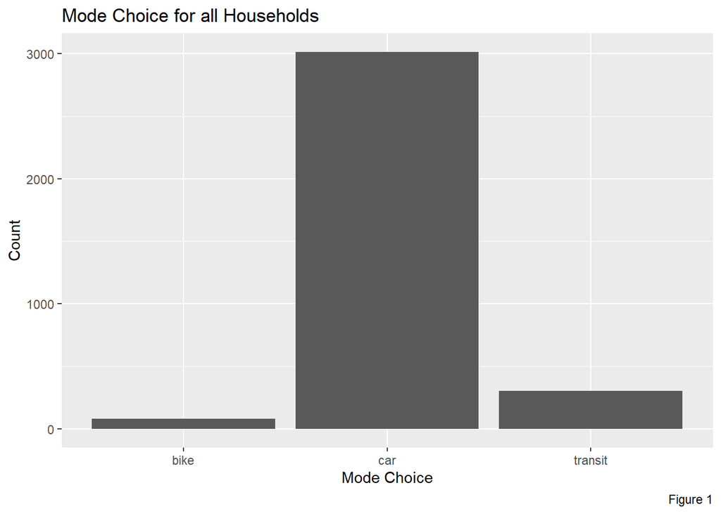

```r
ggplot(dat, aes(x = mode_cat)) +
  geom_histogram(stat = "count") +
  xlab("Mode Choice") + ylab("Count")+
  labs(title = "Mode Choice for all Households",
        caption = "Figure 1")
```

Most of the householders travel by car for their daily trips as well as for their work trips according to Figure 1. This is followed by transit. Very few people use bike as their preferred choice of transportation.

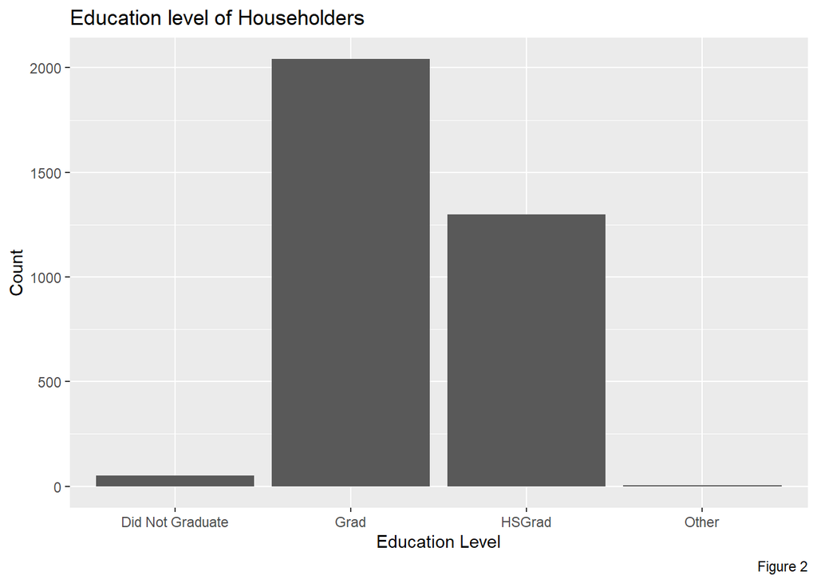

```r
ggplot(dat, aes(x = EDUCA)) +
  geom_histogram(stat = "count") +
  xlab("Education Level") + ylab("Count")+
  labs(title = "Education level of Householders",
        caption = "Figure 2")
```

According to Figure 2 that shows the educational attainment of householders, most of the reported householders hold at least a High School degree. People with some college or graduate level degree make up a significant chunk of our database.

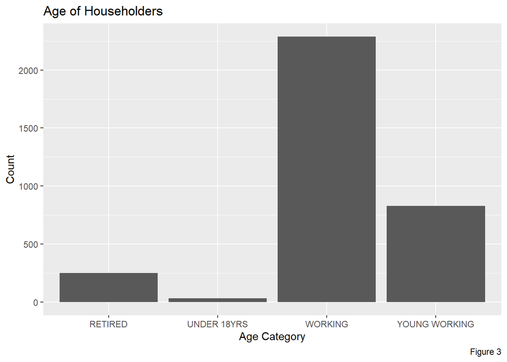

```r
ggplot(dat, aes(x = AGECAT)) +
  geom_histogram(stat = "count") +
  xlab("Age Category") + ylab("Count")+
  labs(title = "Age of Householders",
        caption = "Figure 3")
```

Figure 3 illustrates the age distribution of householders. More than half the users are between 35 to 64 years old. People between the ages of 18 to 34 form th next big chunk. There are very few kids under 18 in our data set. This information is of some importance as they cannot drive on their own and are dependents. There are also a good number of householders who are above 65 years old. The elderly population may require some sort of assistance while traveling, thus their travel pattern should be carefully studied as well.

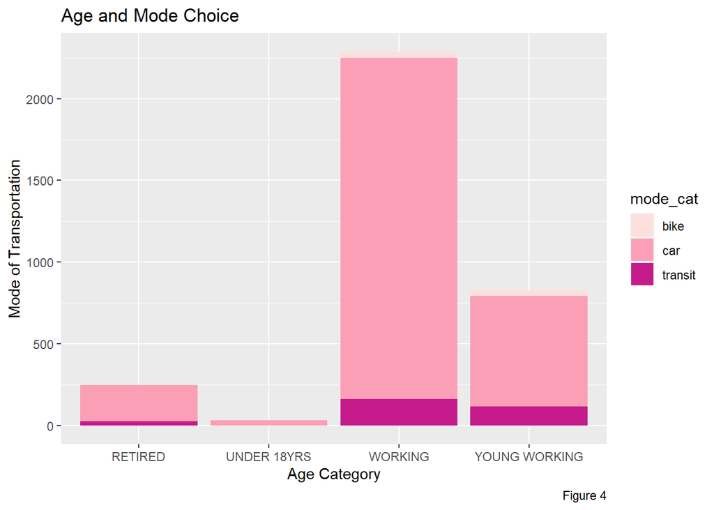

```r
ggplot(dat, aes(x= AGECAT, fill=mode_cat))+
  geom_bar()+
  xlab("Age Category") + ylab("Mode of Transportation")+
    scale_fill_brewer(palette="RdPu")+
  labs(title = "Age and Mode Choice",
        caption = "Figure 4")
```

Figure 4 shows the mode choice for people in different age groups. Most of the users are opt for cars regardless of their age, however people in the age group 25-34 years or young workers use transit as well as bike more than any other age group. Kids under the age of 18 are reported to travel exclusively by car. This suggests that their individual trips may not have been recorded by the survey.

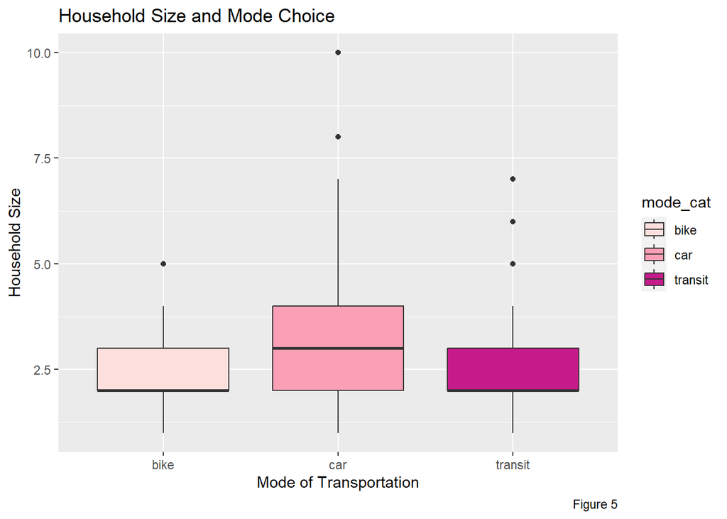

```r
ggplot(dat, aes(x= mode_cat, y= HH_SIZE, fill= mode_cat))+geom_boxplot()+
  xlab("Mode of Transportation") + ylab("Household Size")+
    scale_fill_brewer(palette="RdPu")+
  labs(title = "Household Size and Mode Choice",
        caption = "Figure 5")
```

Figure 5 demonstrates the mode choice by household size. The boxplot suggests that as the household size increases people tend to overwhelmingly prefer travel by car. The number of households traveling by either bike or transit is less compared to those by car. The average size of household traveling by either bike or transit is smaller than those who opt for cars.

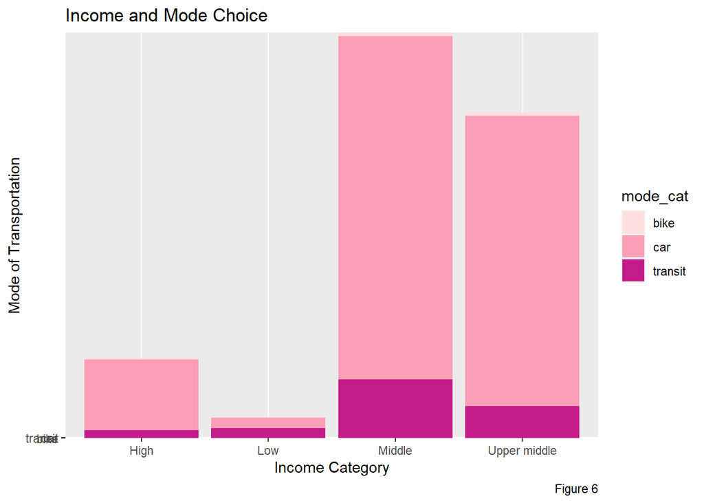

```r
ggplot(dat, aes(x= INCOME, y= mode_cat, fill=mode_cat))+
  geom_bar(stat = "identity")+
  xlab("Income Category") + ylab("Mode of Transportation")+
    scale_fill_brewer(palette="RdPu")+
  labs(title = "Income and Mode Choice",
        caption = "Figure 6")
```

Figure 6 shows the mode choice by income. Our dataset mostly consists of households categorized as Middle and upper middle income holders i.e. people whose annual income falls between 25k to 99k and 99k to 199k (as per 2012). Households under 25k per year are categorized as low income and households above 199k as high income earners. People in the latter group use transit less frequently than those in the former. Biking is unpopular across all income categories.

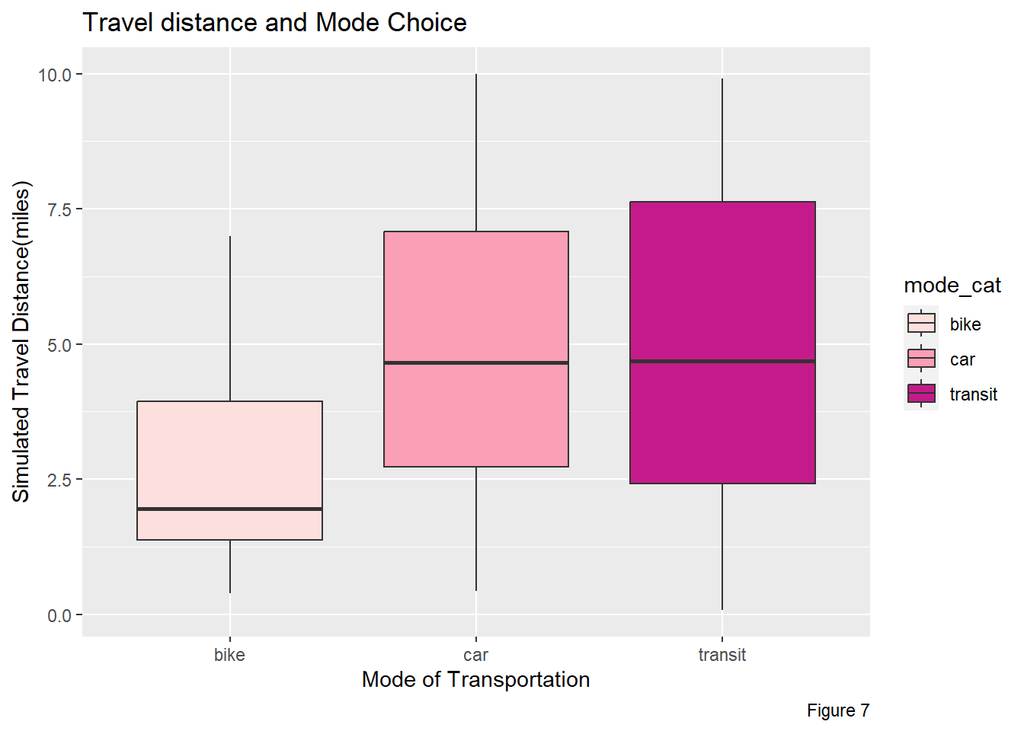

```r
ggplot(dat, aes(x=mode_cat, y=Model_TravDist, fill= mode_cat))+geom_boxplot()+
  xlab("Mode of Transportation") + ylab("Simulated Travel Distance(miles)")+
    scale_fill_brewer(palette="RdPu")+
  labs(title = "Travel distance and Mode Choice",
        caption = "Figure 7")
```

Figure 7 highlights the relationship between simulated travel distance and mode choice. As expected, people use bike for shorter distances (under 4 miles). Transit is competitive with car for longer distance travel with an average travel distance of just under 5 miles for both. People tend to use transit to traverse slightly larger distances when compared to cars.

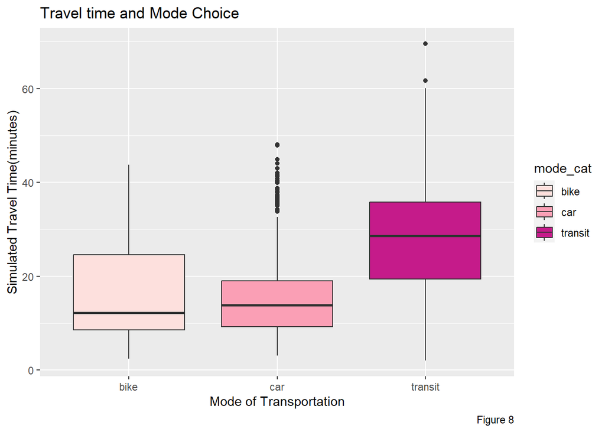

```r
ggplot(dat, aes(x=mode_cat, y=Model_TravTime, fill=mode_cat))+geom_boxplot()+
  xlab("Mode of Transportation") + ylab("Simulated Travel Time(minutes)")+
    scale_fill_brewer(palette="RdPu")+
  labs(title = "Travel time and Mode Choice",
        caption = "Figure 8")
```

## Task 3. Develop the “leanest and meanest” multinomial logit model explaining whether a traveler drove to work, took public transit, or biked. Explain how you used theory, significance level, and model fit to select variables. Briefly discuss which variables fell out in the process of model building and why. Pay particular attention to variables that were hypothesized to correspond to mode choices but were excluded from the final model. For variables that can be modeled as either numerical or categorical, explain your rationale for using either data type. For categorical variables, explain your choice of the reference category (you may set the reference category manually).

Before we develop a multi-nomial logit model explaining whether a traveler drove to work, took public transit, or biked, several steps were undertaken. First, average speeds for each mode were calculated using the given data. Then, travel times for each alternative mode were computed one at a time based on the average speeds and distance data for that mode available in the DVRPC data. A value of 10 or 10 minutes were added to the transit time calculated using this method to account for transfer (boarding and alighting time).

```r
#calculating average speed for each mode
ave.speed <- dat %>% group_by(mode_cat) %>%
  summarise(ave_speed = mean(Model_TravDist/(Model_TravTime/60)))

#calculating travel time for alternative modes, one mode at a time
dat.car <- dat %>% filter(mode_cat == "car")
dat.transit <- dat %>% filter(mode_cat == "transit")
dat.bike <- dat %>% filter(mode_cat == "bike")

dat.car$time.car <- dat.car$Model_TravTime
dat.car$time.transit <- 60*(dat.car$Model_TravDist/ave.speed$ave_speed[3]) + 10 #assigning transfer time
dat.car$time.bike <- 60*(dat.car$Model_TravDist/ave.speed$ave_speed[1])

dat.transit$time.transit <- dat.transit$Model_TravTime + 10
dat.transit$time.car <- 60*(dat.transit$Model_TravDist/ave.speed$ave_speed[2])
dat.transit$time.bike <- 60*(dat.transit$Model_TravDist/ave.speed$ave_speed[1])

dat.bike$time.bike <- dat.bike$Model_TravTime
dat.bike$time.car <- 60*(dat.bike$Model_TravDist/ave.speed$ave_speed[2])
dat.bike$time.transit <- 60*(dat.bike$Model_TravDist/ave.speed$ave_speed[3]) + 10 #assigning transfer time
```

This data is stored as three different dataframe each for car, transit and bike containing 3014, 304 and 79 observations respectively. We notice that the observations for car exceed the observations for other modes. Residents in the DVRPC region overwhelmingly traveled by car. If we were to use the data as it is, our model will predict the mode choice for car very well, however it will not do so for the other modes. This means our model cannot be generalized. Therefore, we take a random sample by setting the seed to 100. set.seed(seed = 100) ensures reproducibility by setting the seed for random number generation. This is important when randomly sampling data to ensure that the same random sample can be obtained in future runs.The sample function is used to randomly sample 500 rows from the dat.car dataset. By doing this, the dataset is reduced to a subset that is more manageable while still retaining a representative sample of car mode data. This step helps balance the representation of each mode in the dataset. This helps prevent bias that may arise if one mode is over-represented or under-represented in the data.

```r
#sub-setting to balance mode choice
set.seed(seed = 100)
rows <- sample(1:nrow(dat.car), 500)
dat.car <- dat.car[rows,]

dat <- rbind.data.frame(dat.car, dat.transit, dat.bike)
```

To make our final multinomial logit model realistic, we assign a monetary cost to each mode of transportation. For driving, a cost of $0.6 per mile is used, multiplied by the travel distance. For transit, a cost of 2 dollar is added as ticket cost and a non-monetary cost of 0.5 is added as a cost of inconvenience while traveling by transit. Similarly for bike, a non-monetary cost of 3 is added as a cost of inconvenience as well as wear and tear on each ride. The data is stored in a new dataframe termed dat.logit.The mlogit.data function from the mlogit package is used to shape the data into the correct format for multinomial logit modeling. The model can now provide insights into how travelers’ decisions are influenced by both monetary and non-monetary costs associated with different transportation modes.

```r
#calculating travel costs for alternative modes
#add $0.6/mile cost for driving
dat$cost.car <- dat$Model_TravDist * 0.6

#multiply 0.5 for non-monetary costs, add $2 for ticket
dat$cost.transit <- dat$Model_TravDist * 0.5 + 2

#add $3 for non-monetary cost and wear and tear
dat$cost.bike <- dat$Model_TravDist + 3

#shaping data into correct format
dat.logit <- mlogit.data(dat, shape="wide",
                      choice="mode_cat",
                      varying=c(18:23))
```

We now start to build our initial model using the cost and time variables we calculated above. These are our alternative specific variables which are not user dependent. We now add individual specific variables that are derived from DVRPC survey one at a time to our model 0.

### Initial Model

```r
#initial model with all variables
#could not run due to multi-collinearity between County and area type
# Set reference level to Urban
dat.logit$A_TYPE <- relevel(dat.logit$A_TYPE, ref = "Urban")
options(scipen=999)
mod.0 <- mlogit(mode_cat ~ cost + time | INCOME +A_TYPE + LIC + HH_SIZE + HH_WORK + TOT_VEH + GEND + EDUCA + AGECAT, data = dat.logit, reflevel = "car", method = "nr")
summary(mod.0)
```

```
##
## Call:
## mlogit(formula = mode_cat ~ cost + time | INCOME + A_TYPE + LIC +
##     HH_SIZE + HH_WORK + TOT_VEH + GEND + EDUCA + AGECAT, data = dat.logit,
##     reflevel = "car", method = "nr")
##
## Frequencies of alternatives:choice
##      car     bike  transit
## 0.566251 0.089468 0.344281
##
## nr method
## 17 iterations, 0h:0m:0s
## g'(-H)^-1g = 4.3E-07
## gradient close to zero
##
## Coefficients :
##                                 Estimate   Std. Error z-value
## (Intercept):bike             -11.5064326 3370.8315052 -0.0034
## (Intercept):transit            2.2756061    1.6386321  1.3887
## cost                          -0.9630161    0.1554581 -6.1947
## time                           0.0052762    0.0101053  0.5221
## INCOMELow:bike                -1.1438104    0.8636869 -1.3243
## INCOMELow:transit              0.2241053    0.6372562  0.3517
## INCOMEMiddle:bike             -2.5229110    0.5130391 -4.9176
## INCOMEMiddle:transit          -0.3663100    0.3675751 -0.9966
## INCOMEUpper middle:bike       -2.0009807    0.5122992 -3.9059
## INCOMEUpper middle:transit    -0.4017872    0.3726623 -1.0782
## A_TYPECBD:bike                -0.9117925    0.8078488 -1.1287
## A_TYPECBD:transit              0.5685065    0.6158619  0.9231
## A_TYPESuburb:bike             -1.1160177    0.3984378 -2.8010
## A_TYPESuburb:transit          -2.1557303    0.2324723 -9.2731
## LIC:bike                       1.2800955    0.7116508  1.7988
## LIC:transit                    2.2582353    0.4900180  4.6085
## HH_SIZE:bike                  -0.1230671    0.2103683 -0.5850
## HH_SIZE:transit                0.0965939    0.1094094  0.8829
## HH_WORK:bike                   1.4275851    0.3440307  4.1496
## HH_WORK:transit                0.7609996    0.1955462  3.8917
## TOT_VEH:bike                  -2.3988692    0.2676571 -8.9625
## TOT_VEH:transit               -1.6035958    0.1716183 -9.3440
## GEND:bike                     -0.1672060    0.3181408 -0.5256
```

[output cut: 41 more lines]

```
## EDUCAHSGrad:transit                      0.849910
## EDUCAOther:bike                          0.999820
## EDUCAOther:transit                       0.623388
## AGECATUNDER 18YRS:bike                   0.999005
## AGECATUNDER 18YRS:transit                0.998108
## AGECATWORKING:bike                       0.425680
## AGECATWORKING:transit                    0.732128
## AGECATYOUNG WORKING:bike                 0.260470
## AGECATYOUNG WORKING:transit              0.819753
## ---
## Signif. codes:  0 '***' 0.001 '**' 0.01 '*' 0.05 '.' 0.1 ' ' 1
##
## Log-Likelihood: -450.13
## McFadden R^2:  0.43678
## Likelihood ratio test : chisq = 698.16 (p.value = < 0.000000000000000222)
```

```r
AIC(mod.0)
```

```
## [1] 972.2573
```

```r
BIC(mod.0)
```

```
## [1] NA
```

## Task 4. In a neatly organized table, present the output from your final model. Summarize your model results in a few paragraphs. Include plots or tables that show how the probabilities of each choice change with interventions to key variables (i.e., simulated effect of interventions).

```r
#final model
mod.1 <- mlogit(mode_cat ~ cost + time | INCOME + A_TYPE + LIC + HH_WORK + TOT_VEH, data = dat.logit, reflevel = "car", method = "nr")
stargazer(mod.1, type = "text")
```

```
##
## ======================================================
##                                Dependent variable:
##                            ---------------------------
##                                     mode_cat
## ------------------------------------------------------
## (Intercept):bike                    6.735***
##                                      (0.907)
##
## (Intercept):transit                 3.460***
##                                      (0.566)
##
## cost                                -0.978***
##                                      (0.153)
##
## time                                  0.010
##                                      (0.010)
##
## INCOMELow:bike                      -2.016**
##                                      (0.826)
##
## INCOMELow:transit                    -0.125
##                                      (0.627)
##
## INCOMEMiddle:bike                   -2.902***
##                                      (0.492)
##
## INCOMEMiddle:transit                 -0.623*
##                                      (0.360)
##
## INCOMEUpper middle:bike             -1.983***
##                                      (0.492)
##
## INCOMEUpper middle:transit           -0.392
##                                      (0.367)
##
## A_TYPECBD:bike                       -0.566
##                                      (0.790)
##
## A_TYPECBD:transit                     0.718
```

[output cut: 18 more lines]

```
##                                      (0.154)
##
## TOT_VEH:bike                        -2.429***
##                                      (0.256)
##
## TOT_VEH:transit                     -1.599***
##                                      (0.165)
##
## ------------------------------------------------------
## Observations                           883
## R2                                    0.415
## Log Likelihood                      -467.619
## LR Test                       663.181*** (df = 20)
## ======================================================
## Note:                      *p<0.1; **p<0.05; ***p<0.01
```

```r
100*(exp(mod.1$coefficients)-1)
```

```
##           (Intercept):bike        (Intercept):transit
##              83997.2629610               3080.8251360
##                       cost                       time
##                -62.4074567                  0.9668638
##             INCOMELow:bike          INCOMELow:transit
##                -86.6847386                -11.7897281
##          INCOMEMiddle:bike       INCOMEMiddle:transit
##                -94.5107711                -46.3570081
##    INCOMEUpper middle:bike INCOMEUpper middle:transit
##                -86.2284550                -32.4366707
##             A_TYPECBD:bike          A_TYPECBD:transit
##                -43.2342896                104.9957829
##          A_TYPESuburb:bike       A_TYPESuburb:transit
##                -71.3624291                -88.4995465
##                   LIC:bike                LIC:transit
##                 18.6235542                458.6633402
##               HH_WORK:bike            HH_WORK:transit
##                224.6170626                119.5146952
##               TOT_VEH:bike            TOT_VEH:transit
##                -91.1847945                -79.7903160
## attr(,"names.sup.coef")
## character(0)
## attr(,"fixed")
##           (Intercept):bike        (Intercept):transit
##                      FALSE                      FALSE
##                       cost                       time
##                      FALSE                      FALSE
##             INCOMELow:bike          INCOMELow:transit
##                      FALSE                      FALSE
##          INCOMEMiddle:bike       INCOMEMiddle:transit
##                      FALSE                      FALSE
##    INCOMEUpper middle:bike INCOMEUpper middle:transit
##                      FALSE                      FALSE
##             A_TYPECBD:bike          A_TYPECBD:transit
##                      FALSE                      FALSE
##          A_TYPESuburb:bike       A_TYPESuburb:transit
##                      FALSE                      FALSE
##                   LIC:bike                LIC:transit
##                      FALSE                      FALSE
##               HH_WORK:bike            HH_WORK:transit
##                      FALSE                      FALSE
##               TOT_VEH:bike            TOT_VEH:transit
##                      FALSE                      FALSE
## attr(,"sup")
## character(0)
```

```r
AIC(mod.1)
```

```
## [1] 975.2379
```

```r
BIC(mod.1)
```

```
## [1] NA
```

### Interpretation:

For the interpretation we have first calculated the percentages using coefficient for each variable. In this model we are dealing with both continuous and categorical variables.

### For Alternative Specific variables:

Cost: As one mode’s cost become 1 dollar more expensive than the other modes, the odds of choosing the mode becomes 62.4% lower relative to the other modes, all else being equal. This association is statistically significant at p< 0.05 (p= 0.0000000001773344).

Time: As one mode’s travel time becomes 1 minute longer than the other modes, the odds of using the mode becomes 0.96% more relative to the other modes, all else being equal. It suggests that a slight gain in travel time does not impact people’s mode choice significantly.

### For Individual Specific Variables:

1. Income’s impact on mode choice:

Low Income: Bike: On average, for people in the low-income earning category (low-income households), the odds of using bike over other modes or 86.6% lower, all else being equal. This association is statistically significant at p< 0.05 (p= 0.0146995).

Low Income: Transit: On average, for householders in low-income households, the odds of using transit over other modes is 11.78% lower when compared to high income households, all else being equal. This association is not statistically significant.

Middle Income: Bike: On average, for people in middle-income households, the odds of using bike over other modes is 94.5% lower when compared to high income households, all else being equal. This association is statistically significant at p< 0.05 (p= 0.0000000036).

Upper Middle Income: Bike: On average, for people in upper middle-income households, the odds of using bike over other modes is 86.2% lower when compared to high income households, all else being equal. This association is statistically significant at p< 0.05 (p= 0.000055).

Upper Middle Income: Transit: On average, for people in upper middle-income households, the odds of using transit over other modes is 32.43% lower when compared to high income households, all else being equal. This association is not statistically significant.

“Based on our discussion above, on average, upper middle income householders and low income householders are similarly less likely to use bike over other modes, when compared to high income households, whereas, middle income householders are far less likely to use bike. On the other hand for transit, on average, middle and upper middle income householders are less likely to use transit over modes followed by low income householders, when compared to high income householders.”

2. Type of neighborhood area’s or location’s impact on mode choice:

CBD: Bike: On average, for people living in the central business district, the odds of using bike over other modes is 43.23% lower when compared to people living in urban areas, all else being equal. This association is not statistically significant.

CBD: Transit: On average, for people living in the central business district, the odds of using transit over other modes is 105% higher when compared to people living in urban areas, all else being equal. This association is not statistically significant.

Suburb: Bike: On average, for people living in suburbs and rural areas, the odds of using bike over other modes is 71.36% lower when compared to people living in urban areas, all else being equal. This association is statistically significant at p< 0.05 (p= 0.0009052).

Suburb: Transit: On average, for people living in suburbs and rural areas, the odds of using transit over other modes is 88.5% lower when compared to people living in urban areas, all else being equal. This association is statistically significant at p< 0.05.

“Based on our discussion above, on average, people living in the CBD are much more likely to use transit over other modes, than people living in urban areas and suburban areas.”

3. Drivers License’s impact on mode choice:

No-License: Bike: On average, for people without a driver’s license, the odds of using bike over other modes is 18.62% higher when compared to people with a license, all else being equal. This association is not statistically significant.

No-License: Transit: On average, for people without a driver’s license, the odds of using transit over other modes is 458% higher when compared to people with a license, all else being equal. This association is statistically significant at p< 0.05 (p= 0.000065).

“On average, people without a licence are more likely to bike or take transit than those with a license.”

4. Number of workers in a household’s impact on mode choice:

HH_worker: Bike: On average, for each additional worker in a household, the odds of using bike over other modes is 225% higher, all else being equal. This association is statistically significant at p< 0.05.

HH_worker: Transit: On average, for each additional worker in a household, the odds of using transit over other modes is 120% higher, all else being equal. This association is statistically significant at p< 0.05.

“On average, people are more likely to take bike or transit than car, if there are more workers within the household.”

5. Number of household vesicle’s impact on mode choice:

No of Vehicle: Bike: On average, for each additional household vehicle, the odds of using bike over other modes is 91% lower, all else being equal. This association is statistically significant at p< 0.05.

No of Vehicle: Transit: On average, for each additional household vehicle, the odds of using transit over other modes is 79.8% lower, all else being equal. This association is statistically significant at p< 0.05.

“On average, people are less likely to take bike or transit over car, if there are more workers vehicles in the household.”

### Model Prediction

An estimate of how good our model is to look at how well the predicts people’s mode choice. The following code predicts the probabilities of each mode (car, transit, bike) using the mod.1 model fitted earlier. It creates a data frame mode.prob containing these predicted probabilities. We calculated the actual share of each mode category in the observed data by dividing the frequency of each mode category in the mode_cat column by the total number of rows. We then assigned thresholds for each mode based on the share: 0.56 for car, 0.34 for transit and 0.08 for bike. A contingency table of the observed and predicted choice has been presented below.

```r
#predicting
mode.prob <- data.frame(predict(mod.1, type = "response", newdata = dat.logit))
dat <- cbind.data.frame(dat, mode.prob)

dat$pred_mode <- 0

#use actual share in observed as thresholds
table(dat$mode_cat)/length(dat$mode_cat)
```

```
##
##       bike        car    transit
## 0.08946772 0.56625142 0.34428086
```

```r
for (i in 1:length(dat$HH_ID)) {
  if (dat$car[i] > 0.56625142) {
    dat$pred_mode[i] = "car"
  } else if (dat$transit[i] > 0.34428086) {
    dat$pred_mode[i] = "transit"
  } else if (dat$bike[i] > 0.08946772) {
    dat$pred_mode[i] = "bike"
  }
}

table(predicted =dat$pred_mode, observed= dat$mode_cat)
```

```
##          observed
## predicted bike car transit
##   bike      18   7       5
##   car        6 429      54
##   transit   55  64     245
```

```r
#Count R squared
countr <- (18+429+245)/ (18+7+5+6+429+54+55+64+245) *100
countr
```

```
## [1] 78.3692
```

```r
#Misclassification error
Misclass <- 100- countr
Misclass
```

```
## [1] 21.6308
```

We have also used the following metric to evaluate the goodness of fit of our model:

Count R squared: Count r2 is the total number of correct predictions over the total number of counts. It is a metric used to evaluate the goodness of fit of a model. In our case the Count R squared is 78.36% i.e. our model predicts 78.36% of the data correctly.

Misclassification error: It represents the proportion of incorrect predictions made by the model. It is calculated a (1- count r squared). It can also be expressed as the sum of false predictions divided by the total number of observations. Lower Misclassification Error indicates higher accuracy of the model in predicting the correct classes. In our case, the model incorrectly predicts 21.63% of mode choice in the data.

### Adding Interventions:

We also wanted to see how well our model would predict if the existing conditions were changed. We made the following changes to our variables:

Cost: People in the Delaware valley region prefer car as a mode of transport. This is also due in part to the convenience and relative ease of purchasing a car in the US and cost of gas. We wanted to see if increasing the cost of driving the car by 50% would have an influence on its popularity. Concurrently, we wanted to check if reducing the cost of transit by 50% at the same time might improve ridership. Higher costs might lead to a decrease in car usage if other factors remain constant. It also aims to test if a reduction in transit costs leads to increased ridership, as lower costs can make transit more attractive compared to other modes of transport.

Time: To promote transit use even further, we also decided to reduce the time of traveling by transit by 20%. This intervention is intended to assess how a reduction in transit time influences people’s decisions regarding mode choice. Shorter travel times might make transit more appealing, potentially increasing its usage.

```r
#how changing variables affect mode choice####

apply(predict(mod.1, type = "response", newdata = dat.logit), 2, mean)
```

```
##        car       bike    transit
## 0.56625141 0.08946773 0.34428086
```

```r
#increasing driving cost by 50%
dat.1 <- dat
dat.1$cost.car <- dat.1$cost.car * 1.5
#reducing transit cost by 50%
dat.1$cost.transit <- dat.1$cost.transit * 0.5
#reducing transit cost by 20%
dat.1$time.transit <- dat.1$time.transit * 0.8

dat.1.logit <- mlogit.data(dat.1, shape="wide",
                           choice="mode_cat", varying=c(18:23))

#average predicted probability for using each mode before and after intervention
mean_mod_1 <- apply(predict(mod.1, type = "response", newdata = dat.logit), 2, mean)
mean_mod_2 <- apply(predict(mod.1, type = "response", newdata = dat.1.logit), 2, mean)

#display table
mean_table <- data.frame(
  Model = c("Model 1", "Model 2"),
  Car = c(mean_mod_1["car"], mean_mod_2["car"]),
  Transit = c(mean_mod_1["transit"], mean_mod_2["transit"]),
  Bike = c(mean_mod_1["bike"], mean_mod_2["bike"]))
print(mean_table)
```

```
##     Model       Car   Transit       Bike
## 1 Model 1 0.5662514 0.3442809 0.08946773
## 2 Model 2 0.1013966 0.8478787 0.05072466
```

## Task 5. Discuss (1) how well your model predicts observed mode choices, (2) for which modes the model predicts best or worst and why, and (3) what methods you used to draw your conclusions.

```r
table(predicted =dat$pred_mode, observed= dat$mode_cat)
```

```
##          observed
## predicted bike car transit
##   bike      18   7       5
##   car        6 429      54
##   transit   55  64     245
```

```r
#correct rate for bike
Bikepred <- (18)/(18+6+55) *100
Bikepred
```

```
## [1] 22.78481
```

```r
#correct rate for car
Carpred <- (429)/(7+429+64) *100
Carpred
```

```
## [1] 85.8
```

```r
#correct rate for transit
Transitpred <- (245)/(5+54+245) *100
Transitpred
```

```
## [1] 80.59211
```

In our case, the model predicts mode choice for bike with only 22.8% accuracy, whereas it predicts car and transit usage with a 85.8% and 80.6% accuracy. Analyzing mode-specific prediction accuracy provides a more nuanced understanding of the model’s strengths and weaknesses. As discussed before, our model predicts the best for car usage and the least for bike usage. This is due to the overwhelming observations for the former compared to the latter in our data being fed to the model. The model’s lower accuracy in predicting bike usage suggests challenges in capturing the complexities of bike mode choice. This could be due to factors such as limited data on biking behavior, variability in biking preferences, or the influence of external factors like weather or infrastructure on bike usage patterns.

# Extra Credit

## DVRPC has hired you as a consultant to discuss what additional variable(s) you would recommend including in its next Household Travel Survey and why. These variables could be ones that reflect the changing transportation landscape since the last survey in 2012 and/or might have helped make your models predict better.

For this question, we have taken into consideration changes in travel pattern due to various policies, physical infrastructure and behavioral changes since 2012. There has been a shift in user trends since the pandemic. Work from home has become more commonplace which would affect the travel pattern for several households. In 2014, Uber was launched in Philadelphia and in 2017 Curb taxi mobile app was launched. These innovations have impacted the mode choice and opened by options. The above two examples have made a significant impact on transportation however these fall under categories “Worked at home for pay” and “Rideshare services”. Therefore they have not been included in the recommendations. We decided to include the following variables:

1. Age: the current DVRPC household survey categorizes age variable. While categorical variable are suitable for looking at impact of travel choices on a group, Using age as a squared continuous variable instead allows us to model nonlinear relationships between age and the outcome variable within a single continuous scale. It can capture curved or U-shaped relationships where the effect of age changes non-linearly.
2. HOV lane: high occupancy vehicle lane or Carpooling lane are special lanes that enable those who carpool or ride the bus to bypass the traffic in the adjacent, unrestricted (“general-purpose”) lanes. These lanes next to a highway or a toll road can reduce travel time. Nearly every State with HOV lanes reports that ridesharing and overall corridor person moving efficiency has increased since the lanes opened. Carpooling along with the use of EZ pass at no-cash tolls can potentially reduce travel delays. Adding it as a variable could help us examine its impact in the Delaware Valley region on time savings and mode choice.
3. Congestion pricing: congestion pricing relies on dynamic pricing strategy designed to regulate demand by increasing prices without increasing supply. It can includes demand or surge pricing, segmented pricing, and peak-user pricing. As congestion pricing is implemented in New York city, we have assumed a case wherein this strategy is implemented in the Delaware Valley as a whole or in just the Philadelphia MSA. Cities like London and Stockholm that have implemented congestion pricing have experienced significant reductions in traffic congestion, improved air quality, and increased use of public transit and active modes. Such a strategy would surely impact the travel pattern and should have its own unique variable identifying if there was congestion pricing and how much did the user pay. This could help to look at what income group is willing to pay, who will shift to a different mode and what is the price threshold for different income groups. Predictions based using congestion pricing in a model with income, age, mode categories etc could surely help planners and engineers design for the future.
4. Simulated congestion pricing: similarly to congestion pricing, it can be simulated based on actual numbers between daily recorded departure TAZ and arrival TAZ determined using a model; based on mode choice. The model could also potentially look at impact of congestion pricing on road safety for pedestrians and fatalities (https://pubmed.ncbi.nlm.nih.gov/35413616/). Simulation models based on congestion pricing scenarios can provide insights into potential travel behavior changes, revenue generation, and environmental benefits.
5. Wait time: in our discussion above we used transit transfer and waiting time as a weighted measure of travel time. We had assumed a mean transfer time value however this information can also be collected directly from the riders as well. We want to look at wait time not just for public transit but also for rideshare services. We believe the wait time for rideshare may be greater in the suburbs or congested downtown which might affect people’s inclination to use it. Research on rideshare services has highlighted the importance of wait times in user satisfaction and mode choice. Thus we want to expand on the usage of the term as a variable in our future database. Collecting data on wait times for different transportation modes can help identify areas with longer wait times, assess user preferences, and improve service planning and operations to enhance the overall passenger experience.
6. Simulated wait time: once we have a database on wait time across different counties and morphologies, We can design a simulation that mimics waiting for a bus over the course of one day or as needed. Simulated wait time scenarios can simulate real-world conditions and help evaluate the impact of infrastructure improvements or service enhancements on wait times. This approach can aid in optimizing transit operations, enhancing user experience, and encouraging modal shifts. Factors such as real-time information systems, transit frequency adjustments, and infrastructure enhancements can be tested through simulations to optimize wait times and promote modal shift as well.